# Coding with an AI agent in VS Code

#### Check that it works

Close the file again and start another new conversation, so that Claude reads the updated `CLAUDE.md`, and ask:

> *Write a script that extracts the first 10,000 reads from a FASTQ file,* *and run it on the R1 file of sample S63*

Notice that this prompt doesn’t say where the FASTQ files are, where the output should go, or how to write the script. Let’s all check what Claude did in response:

- Did it know where to find the FASTQ file, or did it have to search for it? And where did it put the output?
- Check whether the script follows each of the conventions we told it about in `CLAUDE.md`.

We’ll also check whether the output file indeed contains 10,000 reads (40,000 lines) (adjust the path to wherever Claude put your output file):

```bash
zcat results/subset_fastq/S63_R1.fastq.gz | wc -l
```

```
40000
```

**Click to see the response and script I got**

Its initial script had a problem, which it realized as it ran the script, and it then fixed that problem:

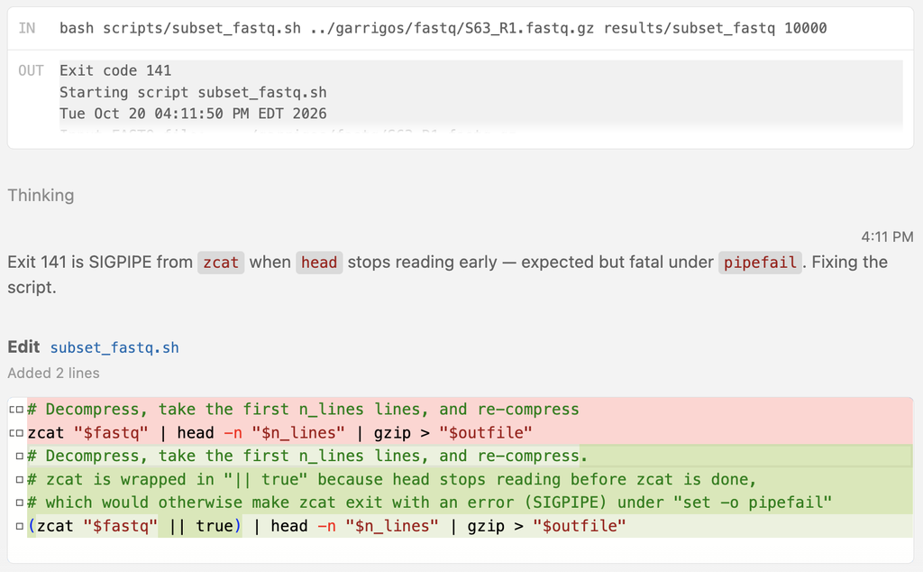

The final script is quite good, and has some nice little explanations in the comments:

```
scripts/subset_fastq.sh
```

```bash
#!/bin/bash
set -euo pipefail

# Extracts the first N reads from a gzipped FASTQ file
# Usage: bash scripts/subset_fastq.sh <FASTQ file> <output dir> <number of reads>

# zcat/head/gzip are standard coreutils already present on the system,
# so no Apptainer container is needed here

# Copy the placeholder variables
fastq="$1"
outdir="$2"
n_reads="$3"

# Initial logging
echo "Starting script subset_fastq.sh"
date
echo "Input FASTQ file:   $fastq"
echo "Output dir:         $outdir"
echo "Number of reads:    $n_reads"
echo

# Create the output dir if needed
mkdir -p "$outdir"

# Each FASTQ read spans 4 lines, so N reads = N*4 lines
n_lines=$(( n_reads * 4 ))

# Output file keeps the input's base name
outfile="$outdir"/$(basename "$fastq")

# Decompress, take the first n_lines lines, and re-compress.
# zcat is wrapped in "|| true" because head stops reading before zcat is done,
# which would otherwise make zcat exit with an error (SIGPIPE) under "set -o pipefail"
(zcat "$fastq" || true) | head -n "$n_lines" | gzip > "$outfile"

# Final logging
echo
echo "Output FASTQ file:  $outfile"
echo "Successfully finished script subset_fastq.sh"
date
```

One caveat: `|| true` hides *any* `zcat` error, not just the harmless one. For example, if the input file doesn’t exist, the script creates an empty output file and still reports success.

**NoteMore on using `CLAUDE.md` *(Click to expand)**

**Keep updating your `CLAUDE.md`**  
Start simple, and add to it whenever you notice yourself telling Claude the same thing again, or Claude making the same mistake again. Be mindful of its length, though: it’s read at the start of every conversation, so it uses up tokens each time.

**Other locations for `CLAUDE.md` files**  
You can also put a `CLAUDE.md` in a parent dir, to apply to several related projects, or at `~/.claude/CLAUDE.md`, to apply to all your projects. See the [documentation on `CLAUDE.md`](https://code.claude.com/docs/en/memory) for details.

**Instructions are not strict rules**  
`CLAUDE.md` contains *instructions*, which Claude will usually but not always follow. To strictly enforce rules, use permission rules. For instructions that you only need for *specific* tasks, see the self-study page on skills.

**`CLAUDE.md` vs. Claude’s memory**  
Besides reading your `CLAUDE.md`, Claude also keeps **memory** notes for itself: when you correct it or tell it about your preferences, it *may* save a note, which is loaded into future conversations in the same project. You can also ask it directly to save memories, e.g. *“Remember that I prefer …”*. Like `CLAUDE.md`, memory notes are plain Markdown files, and they’re stored in your Home dir. Claude writes them itself, but it’s worth checking them now and then.

More broadly, memory notes are another big advantage of AI in your editor. While browser-based chatbots may remember general things about you, here you can save more extensive, specific information about your project and your preferences. You can check Claude’s memory notes by typing `/memory` in the prompt box. More details are on the self-study page.

## 8 Documenting your AI use

As discussed in the previous lecture, journals often require you to disclose how you used genAI, and you can’t count on getting the same answer when you ask the same thing again later. So it’s a good idea to keep a record as you go. Here are two complementary ways to do so.

Let’s start by creating a `doc/ai` dir in your project, to hold AI-related documentation:

```bash
mkdir -p doc/ai
```

### 8.1 Save your conversations

Claude saves your conversations automatically, but in your Home dir rather than in your project, and in a format that’s not easy to read. To save a conversation in your project as a plain-text file, you can use the export slash-command, `/export`, in the prompt box. Let’s practice that now — still in your previous conversation, type:

> /export extract-reads.txt

This will open a Save As dialog, with the suggested file name `extract-reads.txt`. Go ahead and save the file in your `doc/ai` dir.

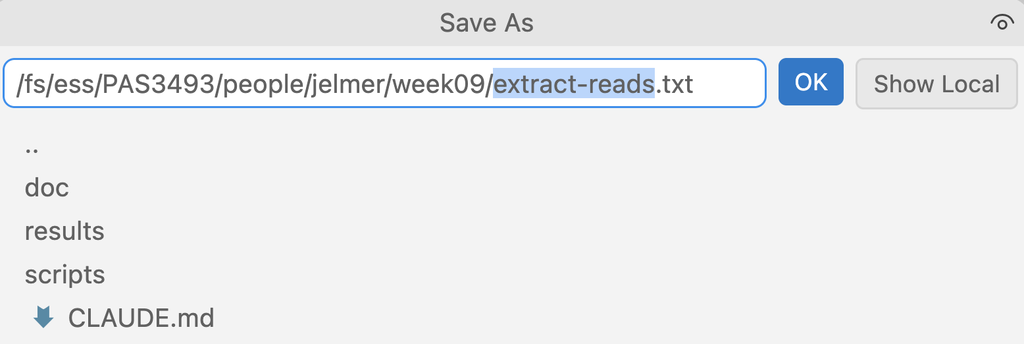

Do this for conversations that helped you produce code you end up keeping, or helped you make decisions about the analysis steps. Consider committing these files to Git as well.

**NoteAutomatically saving all conversations *(Click to expand)**

Exporting by hand is easy to forget. To save every conversation automatically, you can use a **“hook”**: a shell command that Claude Code runs at a specific moment, such as whenever Claude finishes responding. Hooks are run by Claude Code itself rather than by the model, so unlike instructions in `CLAUDE.md`, they always run.

A hook receives the location of Claude’s own file for the current conversation, which contains every message and tool call in a format that’s hard to read. The hook can then run a small script that converts this file into a readable Markdown file in your project, overwriting it each time so it stays up to date.

You don’t have to write this yourself — you can ask Claude to set it up, for example:

> Add a Stop hook to this project’s `.claude/settings.json` that saves the current conversation as a Markdown file in `doc/ai/`. Name each file by the conversation’s start date and session ID, include my prompts and your responses, and summarize each tool call in one line.

Then, have a short conversation and check the resulting Markdown file. A few more tips:

- To use the hook in all your projects, ask Claude to put it in `~/.claude/settings.json` instead.
- Claude deletes its own conversation files from your Home dir after 30 days. To keep them longer, set `cleanupPeriodDays` in `~/.claude/settings.json`.
- See the [hooks documentation](https://code.claude.com/docs/en/hooks) for details.

### 8.2 Let Claude keep a diary

Exported conversations are complete but long. For a concise overview, you can let Claude keep a diary of key findings and decisions — add the following to the end of your `CLAUDE.md` file:

```
CLAUDE.md (excerpt)
```

```markdown
## AI diary

- After completing a task, add an entry at the bottom of `doc/ai/ai-diary.md`
  with the date, what I asked for, which files you created or changed,
  and any key findings and decisions (including alternatives that were rejected)
- Keep entries short
```

Then, close the file, start a new conversation, and ask Claude to make a small change:

> *Make scripts/count_reads.sh print its output as a tab-separated table with a header line*

**Click to see some possible scripts**

Here’s one script I got, which uses `echo -e` so that `\t` is printed as a tab:

```
scripts/count_reads.sh
```

```bash
#!/bin/bash
set -euo pipefail

# Count the number of reads in one or more FASTQ files and print the
# result as a tab-separated table.
# Usage: bash scripts/count_reads.sh <fastq.gz> [fastq.gz ...]

echo -e "file\tn_reads"

# Loop over all FASTQ files given as arguments ("$@").
for fastq_file in "$@"; do
    # Each read in a FASTQ file takes up 4 lines, so divide the line count by 4.
    num_lines=$(zcat "$fastq_file" | wc -l)
    num_reads=$((num_lines / 4))

    echo -e "$fastq_file\t$num_reads"
done
```

In another test-run, it used `printf` instead of `echo -e`:

```
scripts/count_reads.sh
```

```bash
#!/bin/bash
# Usage: count_reads.sh <fastq.gz> [fastq.gz ...]

# Print a tab-separated header, then loop over all FASTQ files given as arguments ("$@").
printf "file\tnum_reads\n"
for fastq_file in "$@"; do
    # Each read in a FASTQ file takes up 4 lines, so divide the line count by 4.
    num_lines=$(zcat "$fastq_file" | wc -l)
    num_reads=$((num_lines / 4))

    printf "%s\t%s\n" "$fastq_file" "$num_reads"
done
```

After editing the script, Claude may ask you about a diary entry, like so — you can then simply type “Yes” to reply:

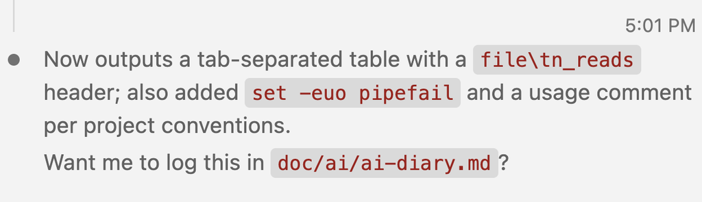

Alternatively, it may go ahead and add an entry itself, but should then mention that it did so. Let’s check whether the file exists, and if so, what it contains. Here’s what I got:

```
doc/ai/ai-diary.md
```

```markdown
# AI diary

## 2026-10-21

Asked for: make `scripts/count_reads.sh` print output as a tab-separated table
with a header line.

Changed: `scripts/count_reads.sh` — added a `file\tn_reads` header,
switched the per-file output to tab-separated.

Also brought the script in line with project shell conventions
(`set -euo pipefail`, purpose/usage comment block) since it was missing those.
```

Note the last two lines: Claude also brought the script in line with two conventions from our `CLAUDE.md`, which didn’t exist yet when it first wrote `count_reads.sh`. That’s helpful here, but it’s a change we didn’t ask for: always check the full diff, not just the part you asked for. (The diary made this change easy to spot.)

Like any `CLAUDE.md` instruction, Claude will **usually** but not always follow it. And the diary is Claude’s own summary of what happened: read it, correct it where needed, and commit it to Git along with your code.

## 9 Managing context and cost

### 9.1 Agents fill up the context window quickly

Recall from the previous lecture that a model’s **context window** holds everything in the conversation, and that performance degrades as it fills up. With an agent, this happens much faster than with a chatbot: every file Claude reads and every command output it sees goes into the context too.

The size of the context window depends on the model. Current Claude models can hold up to 1 million tokens (very roughly 750,000 words), but some models and setups use a smaller window of 200,000 tokens.

To see how full the context window is, type **`/context`** in the prompt box. At the top, this shows which model you’re using, and how many tokens are in use out of that model’s context window size.

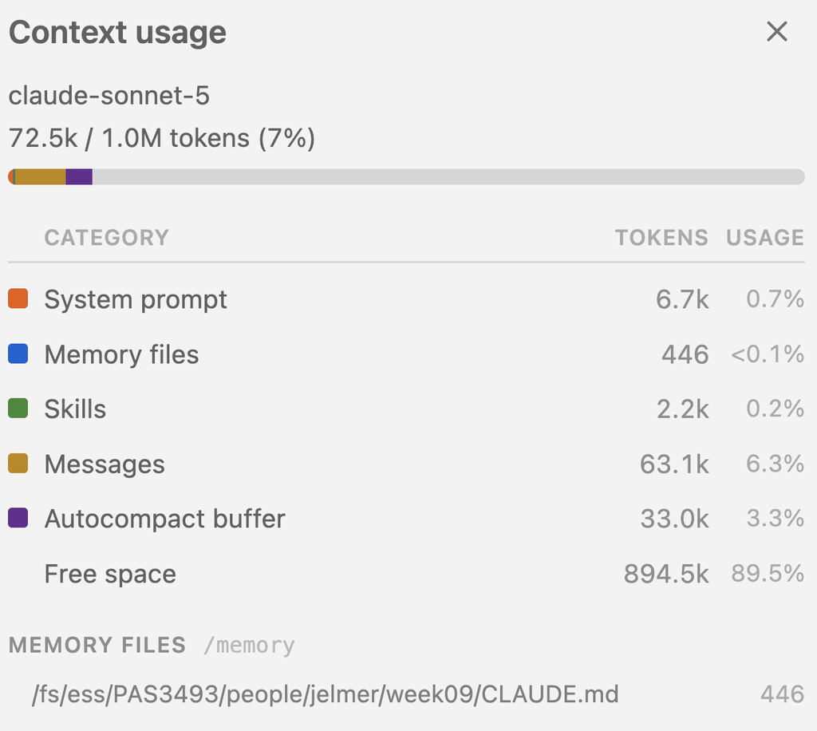

**NoteAbout the context categories *(Click to expand)**

These categories are shown in the screenshot above:

- **System prompt**: Claude Code’s built-in instructions, the same in every conversation.
- **Memory files**: your `CLAUDE.md` file(s), which are listed below the table, and Claude’s own memory notes, if any.
- **Skills**: short descriptions of available “skills” (see this optional material to learn more about skills).
- **Messages**: everything in the conversation so far, including files Claude read and command output it saw. This grows as the conversation moves along: in every turn (new prompt and response), all previous messages are sent to the model again along with your new prompt, so each turn processes more tokens than the one before (see the box on caching below).
- **Autocompact buffer**: space reserved for summarizing the conversation once the context window is nearly full (see `/compact` below).
- **Free space**: what’s left.

Depending on your setup, you may also see other categories, like **System tools**: descriptions of the tools Claude can use, like reading files.

**TipCaching: what gets reprocessed with every message *(Click to expand)**

Models don’t remember anything, not even between individual rounds of prompts and answers (“turns”) in a conversation.

With every new prompt, the *entire* context (the system prompt, your `CLAUDE.md`, and all earlier messages, including files Claude read and command output) is sent to the model again and processed as input tokens.

To make this faster and cheaper, the part of the context that hasn’t changed since the previous turn is **cached**: temporarily stored, so that it doesn’t need to be fully reprocessed. Cached input tokens cost only a fraction of the regular price (for Sonnet, about one tenth). Only your new prompt and everything Claude does in response are processed at the full price.

However, the cache **expires** after it hasn’t been used for a while, and it’s specific to a model. After the cache expires or when you switch models, the next message reprocesses the entire conversation at the full price.

With an API key like ours, the cache expires after only **5 minutes** without activity. The clock icon in the prompt box (e.g., `4m`) shows how much time is left. (With a personal subscription, Claude Code keeps the cache for an hour instead: that costs more per cached token, which doesn’t matter with a fixed monthly fee but does when you pay per token.)

Some practical consequences:

- When you come back to a long conversation after a break of more than a few minutes, consider starting a new conversation instead, unless you really need what was discussed before.
- Choose your model at the start of a conversation, rather than switching back and forth during it.
- Even with caching, every turn in a long conversation costs more, sometimes significantly more, than one in a short conversation, which is another reason to start fresh often.

### 9.2 Start fresh often

Throughout this session, we’ve started a **new conversation** for each new task. That’s a good habit: Claude can get confused when you switch topics within a conversation, and a long conversation is slower and more expensive.

In a new conversation, Claude is at least in principle completely **unaware** of what was said in earlier ones. However, it does read your `CLAUDE.md` and its own memory notes, and it may read files like a diary (as discussed above), either on its own or because `CLAUDE.md` tells it to.

**NoteThe `/clear` and `/compact` slash commands *(Click to expand)**

Two slash commands related to this:

- **`/clear`** (or `/new`) also starts a new conversation. It may look like it deletes the current conversation, because it doesn’t visibly switch to a new one like the new-conversation icon does, but the previous conversation is still available under the clock icon.
- **`/compact`** replaces the conversation so far with a summary, to free up space. Claude also does this automatically when the context window is nearly full. This is useful and clever behavior, though details can get lost in the process.

### 9.3 Models and effort levels

Click on `Sonnet 5 Medium` in the bottom-right of the prompt box to open the model and effort menu:

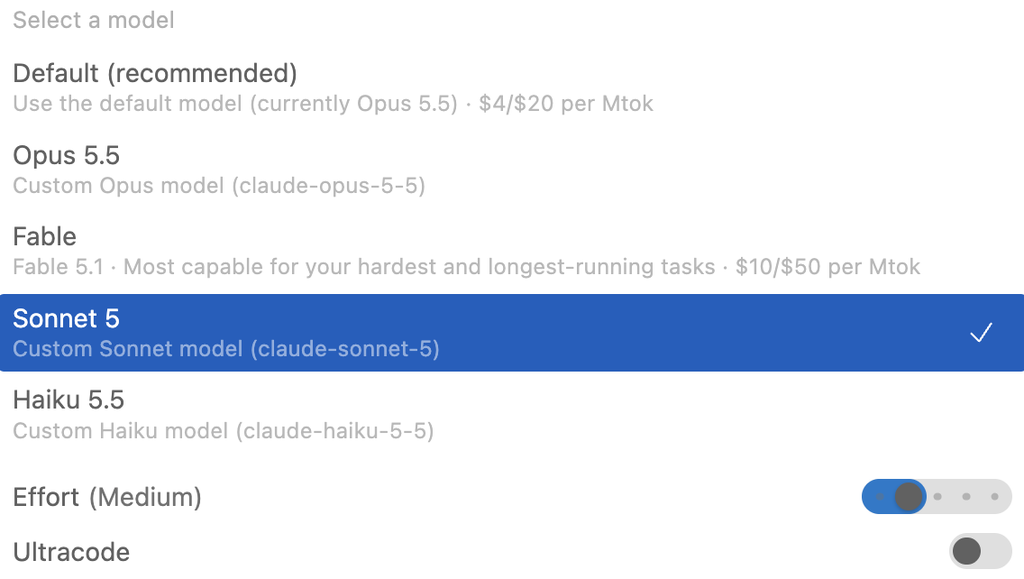

**Models** — The checkmark shows the model you’re currently using. Claude comes in four model “tiers”, listed here from most to least capable:

- *Fable*: the most capable and by far the most expensive model. Meant for very hard and long-running tasks, so you’re unlikely to need it in this course (I’ve never used it). *Don’t use as part of this course.*
- *Opus*: very capable, but slower and more expensive than Sonnet. Can be worth it for more complex questions. *Generally avoid for this course.*
- *Sonnet*: fast, capable, and much cheaper. Plenty for writing and editing scripts like ours. This is the **default** we’ve set in the settings file, and the one you should use most of the time.
- *Haiku*: the fastest and cheapest, for simple questions and quick edits.

**WarningTwo things in this menu can be confusing**

- The **“Default (recommended)”** entry at the top is *not* the model you set in your settings file. It is Claude Code’s own built-in default (currently Opus), which it would use if you hadn’t picked a model at all. Selecting it switches you to Opus, so you’ll use up your budget faster — not recommended except when you think you really need a more capable model.
- Most entries say **“Custom … model”**. This is because our settings file specifies exactly which model version each tier should use (the `ANTHROPIC_DEFAULT_..._MODEL` lines).

**Effort** — How much the model “thinks” before responding: Low, Medium, High, Extra-high, or Max. More effort can give better answers to hard problems, but is slower and uses more tokens. Medium is a good default for our purposes.

**Ultracode** — keep this set to off (for more details, see the box below).

In summary, we’ll stick to our settings file’s default of Sonnet 5 Medium, but you now know how to change it if you want to try a different model or effort level.

**Note“Ultracode” and “Thinking” toggles *(Click to expand)**

**Ultracode**  
A brand-new toggle that is separate from the effort level. When it’s on, Claude handles every substantial task with a so-called “workflow”: a script that runs many Claude “subagents” in parallel, for example one per file, plus agents that double-check each other’s work. This is meant for large jobs such as auditing or modifying hundreds of files, and it makes each request use many more tokens and take longer.

**Thinking**  
Earlier versions of Claude Code had a separate toggle to turn “thinking” on or off, and you may still see it in online tutorials and videos. This toggle has disappeared because recent Claude models always think, and decide for themselves how much thinking each step needs. The effort level is now *the* way to control this: a lower effort level means less thinking, and a higher one means more.

### 9.4 Cost

Once the budget is used up, Claude will reply with a message like that shown below — if that happens, let us know.

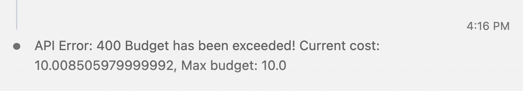

Besides your choice of model and effort level (see above), some other things to know about costs of your conversations:

- **Output tokens** (Claude’s responses, including its “thinking”) cost several times more than input tokens.
- **Agentic tasks** can use many tokens, even when the visible conversation is short, because Claude reads files and command outputs behind the scenes (see also the section on context windows above).
- **Large data files**: Claude Code limits how much of a file or command output it takes in at once, and it’s smart about using commands like `head` and `grep` to look at data files. Still, large data files can quickly fill up the context window and cost a lot, so don’t ask it to “read” them[^5].

To see an **estimate** of what the current conversation has cost so far, type `/usage` — example output is shown in the screenshot on the right.

This information is somewhat limited, e.g. you can’t see usage for other conversations, or how much you’ve used in total for this API key.

(When you have a personal subscription, more detailed usage information is provided.)

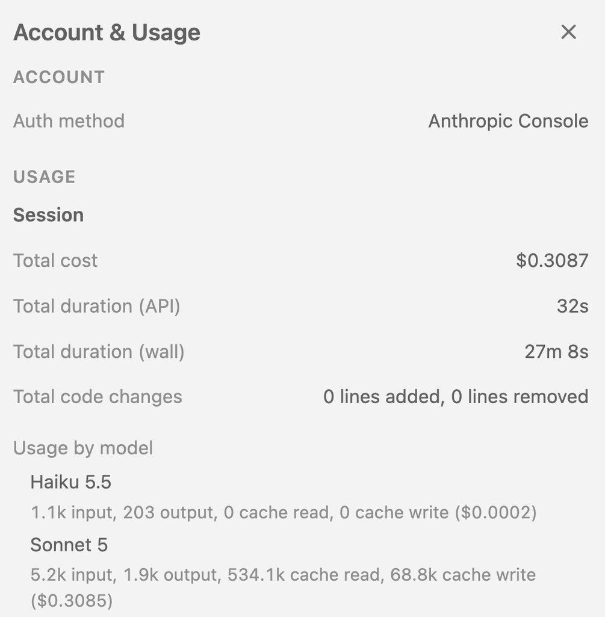

**NoteAPI pricing vs. personal subscriptions *(Click to expand)**

Paying per token through an API key, as we do here, is **much** more expensive than a personal subscription to a service like Claude, which has a fixed monthly fee. A day of heavy agentic coding through an API can easily cost more than a month’s subscription.

If you want to try Claude for personal projects (and/or projects that don’t involve institutional data), a personal subscription is worth considering for this reason — though it will then be *you* who’s paying.

**NoteUsing a personal account in a research project *(Click to expand)**

Personal accounts are not approved for institutional data, which includes your unpublished research data. But much of what an AI agent helps you with only involves your **code**. So you *may* be able to use a personal account in a research project, as long as you make sure that the AI can’t see your data:

- **Make Claude ignore files** with a deny rule (see permission rules), such as `"Read(//fs/ess/PAS1234/myproject/data/**)"`. This blocks Claude’s own file reads as well as common commands like `cat` and `head`, but not, for example, a script that opens the files by itself.
- **Keep your data outside the workspace.** Claude reads files in your workspace without asking, but asks for permission before accessing anything outside of it. This is at odds with our recommendation to keep everything for a project in one self-contained project dir, which you then open as your workspace. But you can keep that project structure and open only a subdir as the workspace: for example, open `myproject/scripts` rather than `myproject`, and decline any request to access `myproject/data`. The downside is that Claude can then also not freely see the rest of your project, such as your results and README.

Keep in mind that anything that ends up in the conversation is sent to the AI, including the output of commands it runs (e.g. a script that prints part of your data) and anything you paste into a prompt. And none of the above is watertight. When in doubt, check with your advisor, or use an OSU-approved tool.

## 10 Good habits when working with an agent

#### Getting good help

- **Be explicit.** Point Claude to the relevant files, and put your conventions and rules in `CLAUDE.md`.
- **Start fresh** for each new task, and keep conversations focused.
- **Use it to raise your standards.** Ask it for things that make code more robust but are easy to skip, like input checks, usage messages, comments, and a README (King et al. 2026).

#### Checking and keeping the results

- **You own the result.** Read every proposed edit and command before approving it.
- **Verify, don’t trust.** When Claude says something “works”, that may be a prediction rather than a test result. Run the code yourself, and check results independently.
- **Results should come from code you can rerun.** Let Claude help you write code that you review, run, and keep; don’t rely on numbers or conclusions it only reports in the chat.
- **Commit before, review after.** Use Git so that you can see and undo what Claude changed.
- **Keep a record.** Commit the code that Claude helped write, and document how you used AI, for example with exported conversations and a diary. You can’t count on getting the same answer if you ask again later.

#### Protecting secrets and data

- **Keep secrets out of prompts.** Never paste passwords or API keys into a prompt.
- **Remember that Claude can see what you can see.** In shared dirs like `/fs/ess/PAS3493`, that may include other people’s files and data. Keep Claude’s workspace limited to your own project.

**TipYou don’t always need an agent**

For general questions, like explaining a concept or a command, a browser-based chat like Gemini (through your OSU account) works just as well and doesn’t use your API key’s budget. Use Claude when it helps that it can see your files and run commands.

If you *do* ask Claude Code simpler questions that don’t require it to read files or run commands, it sometimes helps to explicitly tell it to *“answer from your general knowledge”* or *“don’t read any files”*.

**TipUse Git as a safety net *(Click to expand)**

Version control pairs very well with agentic AI: commit your work before asking Claude for a bigger change, review all of its changes afterwards with `git diff` or the Source Control panel, and undo anything you don’t want with `git restore <file>`. For more on this and other guardrails, such as permission rules that block specific actions, see the self-study page on Claude Code.

Back to top

## References

King, Rachel A., Laurel Abowd, Carlo W. Broderick, et al. 2026. “Ten Simple Rules for Effective Use of Generative AI for Code Development in Environmental Science.” *PLOS Computational Biology* 22 (8): e1014627. https://doi.org/10.1371/journal.pcbi.1014627.

## Footnotes

[^1]: as before, use `Ctrl/Cmd` + click in the terminal, or click `File` > `Open File` > type `~/.claude/settings.json`.
[^2]: or click the upward arrow in the bottom-right corner of the box.
[^3]: Conversations are given a default name based on the first prompt you sent, as also visible in the screenshot above, but these names can be changed by clicking the pencil icon next to them.
[^4]: Many other AI coding tools use a similar file called `AGENTS.md`. Claude reads that file too, but by default only if there is no `CLAUDE.md`.
[^5]: As pointed out before: Claude should help you write code that reads and analyzes data, rather than reading and “analyzing” data itself.